# Species Distribution Model_Inclass

```r
library("dismo")
```

Inport Data

```r
summary(obs.data)
```

[output not shown]

```r
# Notice NAs - drop them before proceeding
obs.data <- obs.data[!is.na(obs.data$latitude), ]

# Make sure those NA's went away
summary(obs.data)
```

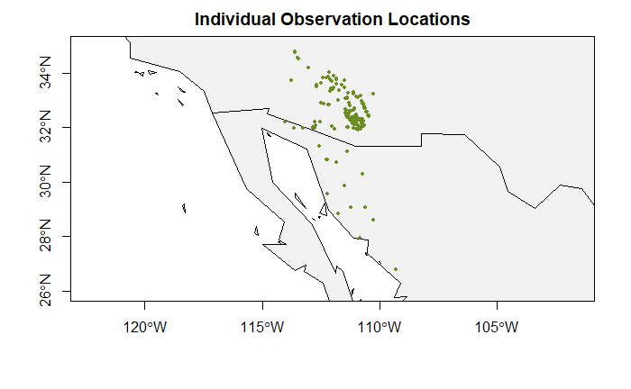

Building a model and visualizing results

```r
# Build species distribution model
bc.model <- bioclim(x = bioclim.data, p = obs.data) #problem with the data format that bioclim wont run.
```

[output not shown]

```r
# Build species distribution model
bc.model <- bioclim(x = bioclim.data, p = obs.data)
```

[output not shown]

|  | latitude | longitude |
| --- | --- | --- |
| 1 | 32.33556 | -110.8980 |
| 2 | 32.28267 | -110.9028 |
| 3 | 30.29105 | -110.7213 |
| 4 | 32.05413 | -110.6837 |
| 5 | 32.25111 | -110.7169 |
| 6 | 32.19404 | -111.0198 |

Reverse the columns (x,y) so that is (longitude, latitiude)

Predict presence from model

Plot

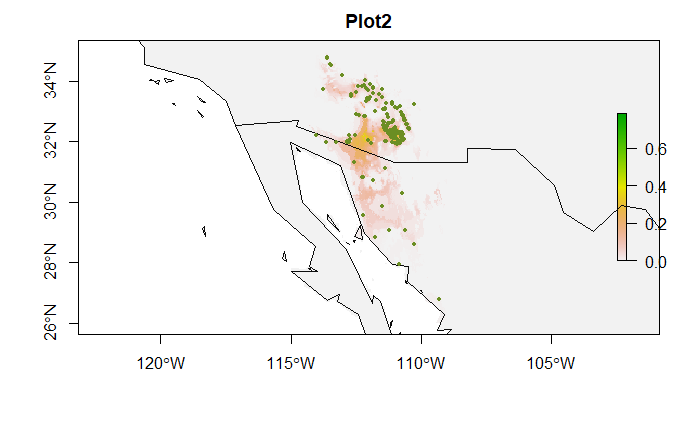

The pseudo-absence point

```r
head(background)
```

```
             x        y
[1,] -114.3542 32.72917
[2,] -112.6458 26.81250
[3,] -110.3125 30.43750
[4,] -111.5625 30.22917
[5,] -112.9375 27.27083
[6,] -108.3958 30.43750
```

We can also visualize them on the map, like we did for the observed points:

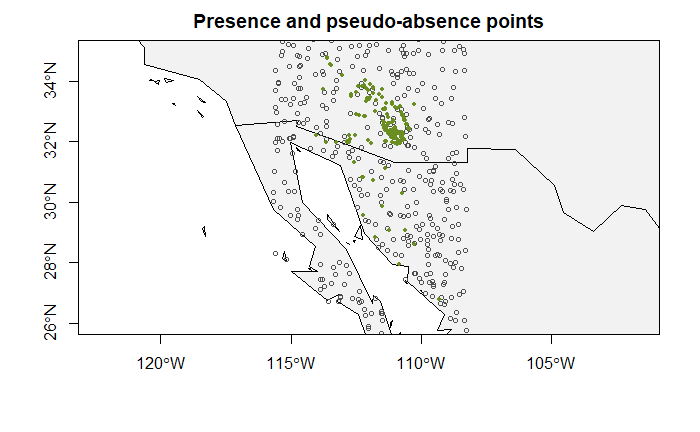

Now that we have our pseudo-absence points, we need to take one more step. Getting a more traditional-range-map-looking figure requires post hoc evaluation of the model. To do this evaluation, we are going to build the model using only part of our data (the training data), reserving a portion of the data for evaluation of the model after it is build (the testing data). We are going to reserve 20% of the data for testing, so we use the kfold function in the dismo package to evenly assign each observation to a random group.

Now pause for a minute and take a look at that group.presence vector we just created:

```r
head(group.presence)
```

```
[1] 2 3 3 4 2 2
```

```r
# Should see even representation in each group
table(group.presence)
```

```
group.presence
 1  2  3  4  5
80 80 80 80 80
```

The output of table shows how many points have been assigned to each of the five groups. In this case, we can see that the points have been evenly distributed, with 20% of the points in group 1, our testing group.

We use the group.presence vector with the observed data to separate our observations into a training data set and a testing data set:

Training and testing

Now that we have (1) our pseudo-absence points and (2) separate training and testing data, we can re-build the model, evaluate its performance, and draw a more aesthetically pleasing map. We build the model with the bioclim function as before, but instead of using all the observations in obs.data we only use the training data stored in presence.train:

We now take that model, and evaluate it using the observation data and the pseudo-absence points we reserved for model testing. We then use this test to establish a cutoff of occurrence probability to determine the boundaries of the saguaro range.

The threshold function offers a number of means of determining the threshold cutoff through the stat parameter. Here we chose “spec_sens”, which sets “the threshold at which the sum of the sensitivity (true positive rate) and specificity (true negative rate) is highest.” For more information, check out the documentation for threshold (?threshold, remember?).

And finally, we can use that threshold to paint a map with the predicted range of the saguaro!

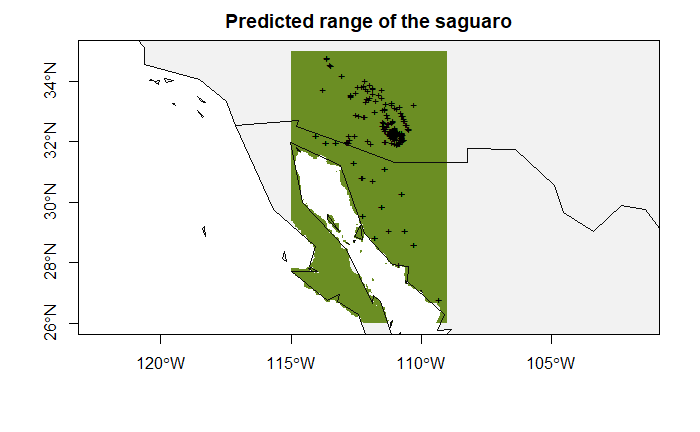

Plot above does not look right.. t plotted a large portion of the map green. Let’s look at what we actually asked R to plot, that is, we plot the value of predict.presence > bc.threshold. So what is that?

```r
predict.presence > bc.threshold
```

```
class      : RasterLayer
dimensions : 216, 144, 31104  (nrow, ncol, ncell)
resolution : 0.04166667, 0.04166667  (x, y)
extent     : -115, -109, 26, 35  (xmin, xmax, ymin, ymax)
crs        : +proj=longlat +datum=WGS84 +ellps=WGS84 +towgs84=0,0,0
source     : memory
names      : layer
values     : 0, 1  (min, max)
```

The comparison of these two rasters produces another raster with values of only 0 or 1: 0 where the comparison evaluates as FALSE (i.e., when the value in a grid cell of predict.presence is less than or equal to the value in the corresponding grid cell of bc.threshold) and 1 where the comparison evaluates at TRUE. Since there are two values in this comparison (the 0 and 1 in the values field), we need to update what we pass to the col parameter in our plot call. Instead of just passing a single value, we provide a color for 0 (NA) and a color for 1 (“olivedrab”):

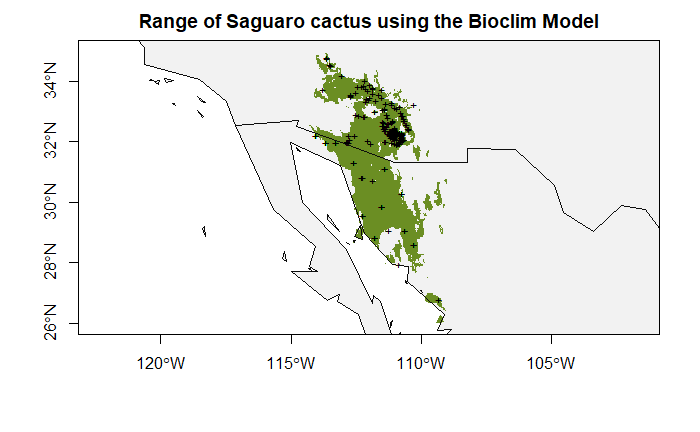

A final note on our approach: the map we have drawn presents a categorical classification of whether a particular point on the landscape will be suitable or not for the species of interest. This classification relies quite heavily on the value of the threshold (see bc.threshold and the documentation for threshold) and the pseudo-absence points. Given that we used random sampling to generate those pseudo-absence points, there is potential for variation in the predicted range if you run this code more than once (try it! if you re-run the code from the point of creating the pseudo-absence points, you are almost guaranteed a different map.). There are a number of approaches to dealing with this variation, and the paper by Barbet-Massin et al. (2012) is a great resource. I’ll leave it as homework for you to determine which approach is most appropriate here!

```r
summary(bioclim.data_2)
```

```
        bio1 bio2 bio3 bio4 bio5 bio6 bio7 bio8 bio9 bio10 bio11 bio12 bio13 bio14 bio15 bio16 bio17 bio18 bio19
Min.      31  113   37 3083  199 -118  238   56   54   110   -41    51    10     0    32    24     0     7    16
1st Qu.  171  158   46 5366  344    2  301  222  192   251    87   145    27     1    54    64     4    52    45
Median   203  167   50 6421  366   38  340  269  217   278   122   289    58     3    68   142    14   122    65
3rd Qu.  219  174   53 7225  385   64  363  295  236   302   147   440    92     6    90   221    30   192    94
Max.     259  204   63 8495  428  121  413  329  276   340   189  1060   317    23   138   736    85   715   230
NA's    6888 6888 6888 6888 6888 6888 6888 6888 6888  6888  6888  6888  6888  6888  6888  6888  6888  6888  6888
```